# 7CS070/UZ3: Concepts & Technologies of Artificial Intelligence

## Creating the Model

```python
# The transformed price feature is extracted form the input variable set X, and placed as the target variable y
X = data.drop(columns=['transformed_price'])
y = data['transformed_price']
```

```python
# The processed dataset is split into training and test set, with test set being 1/5th of its parent dataset
X_train, X_test, y_train, y_test = train_test_split(X, y, test_size=0.2, random_state=0)
```

```python
# Use the standardscaler to standardise the x train and x test sets according to their mean and standard deviation
scaler = StandardScaler()
X_train_scaled = scaler.fit_transform(X_train)
X_test_scaled = scaler.transform(X_test)
```

```python
# Apply a random forest on the training dataset
rf_algorithm2 = RandomForestRegressor(random_state=42)
rf_algorithm2.fit(X_train_scaled, y_train)
# The trained regresser model is then used to predict output values for the given test set
predictions = rf_algorithm2.predict(X_test_scaled)
```

```python
# Determining the MSE (mean squred error) between actual and predicted scores, an MSE as low as 7.38e-05 indicates strong model accuracy
mse_rf = mean_squared_error(y_test, predictions)
# Similarly the R2 score, obtained to be around 0.87 highlights the goodness of the model fit to the test data values,
# given it is approximate to the max R2 score of 1.
r2_rf = r2_score(y_test, predictions)

print("Random Forest Results:")
print(f"Mean Squared Error (MSE): {mse_rf}")
print(f"R² Score: {r2_rf}")
```

```
Random Forest Results:
Mean Squared Error (MSE): 7.384320879310252e-05
R² Score: 0.8728524023318514
```

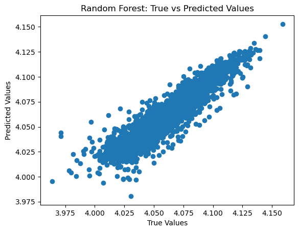

```python
plt.scatter(y_test, predictions)
plt.xlabel('True Values')
plt.ylabel('Predicted Values')
plt.title('Random Forest: True vs Predicted Values')
plt.show()
```

Observing the scatter plot, a generally linear relationship is clear between the actual housing price values and those predicted by the model. This, alongside the retrieved R2 score, supports the claim that the trained model performs accurately. More deviations in model accuracy is observed for lower housing prices, this could be attributed to a limited variation of training data with small prices obtained from the given dataset.

```python
# The MSE and R2 score values for the model performance is retrieved after training with different random seeds ten times
random_forest_mse = [
    7.397599590784965e-05,
    7.553915449696268e-05,
    7.499789204376533e-05,
    7.594718437440048e-05,
    8.121822966720215e-05,
    7.470505270605539e-05,
    7.482236612875883e-05,
    8.227877570552987e-05,
    7.831993121043867e-05,
    8.046424237353279e-05,
]
random_forest_r2 = [
    0.8726237616360132,
    0.8749859217899872,
    0.8771546943948434,
    0.8671043163972778,
    0.8662945911702751,
    0.8745064808886273,
    0.8715733366183398,
    0.8672694205751789,
    0.8715879089548633,
    0.8625678037468744,
]
```

```python
average_random_forest_mse = sum(random_forest_mse) / len(random_forest_mse)
average_random_forest_r2 = sum(random_forest_r2) / len(random_forest_r2)

print("Average Random Forest MSE:", average_random_forest_mse)
print("Average Random Forest R²:", average_random_forest_r2)
```

```
Average Random Forest MSE: 7.722688246144959e-05
Average Random Forest R²: 0.8705668236172281
```

```python
# After several seeds of training, the MSE and R2 score averages out to values of 7.72e-05 and 0.87 respectively.
# underlining the overall good performance of the trained random forest regression model in determining housing prices

average_random_forest_mse = sum(random_forest_mse) / len(random_forest_mse)
average_random_forest_r2 = sum(random_forest_r2) / len(random_forest_r2)

print("Average Random Forest MSE:", average_random_forest_mse)
print("Average Random Forest R²:", average_random_forest_r2)
```

```
Average Random Forest MSE: 7.722688246144959e-05
Average Random Forest R²: 0.8705668236172281
```